# Lab 1

Author

Conie O’Malley

Published

January 20, 2025

## Part 1: Hello World and Beyond

### Issuing Interactive Commands & Adding Comments

```
[1] "Hello World!"
```

```
[1] "Hello Stats!"
```

```
Hello World!
```

```
Hello Stats!
```

### Doing Simple Math Calculations

```
[1] 15
```

```
[1] 15
```

### Creating and Using Vectors and Operations

```
[1] 1 2 3 4 5
```

```
[1] 1 2 3 4 5
```

```
[1] 15
```

### Storing and Calculating Values

```
[1] 11 12 13 14 15
```

```
[1] 11 12 13 14 15
```

```
[1] "Hello"
```

```
[1] "Hello"  "World!"
```

```
[1] "Hello"  "World!"
```

### Navigating the RStudio Workspace

```
[1] "h"  "hw" "x"  "y"  "z"
```

```
[1] "h"  "hw" "x"  "y"
```

### More Practice Vectorizing & Vectors of Unequal Length

```
[1] 38
```

```
[1] "John Kennedy"       "Jacqueline Kennedy" "Robert Kennedy"
```

```
[1] "John Kennedy"               "Jacqueline Kennedy-Onnasis"
[3] "Robert Kennedy"
```

## Part 2: Statistical Analysis with R

### Scatter Plot

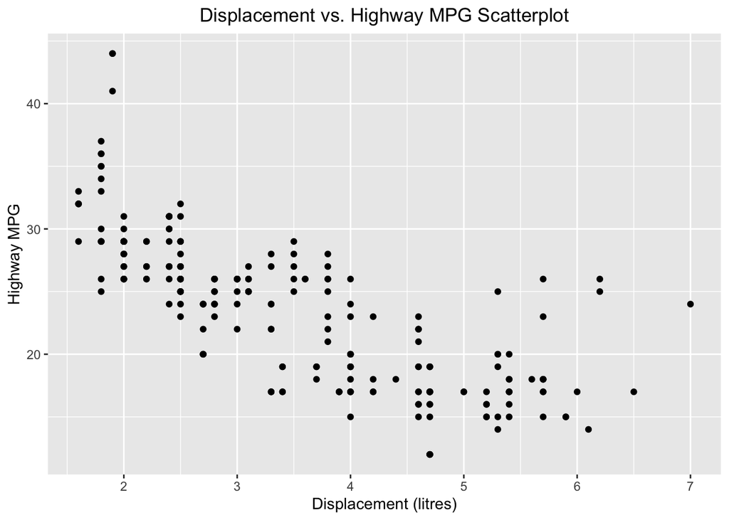

#### Analysis

There is a inverse relationship between the volume of engine displacement and highway miles per gallon. The relationship appears to be slightly curvilinear, but cannot be confirmed without a residuals plot.

### Box Plot

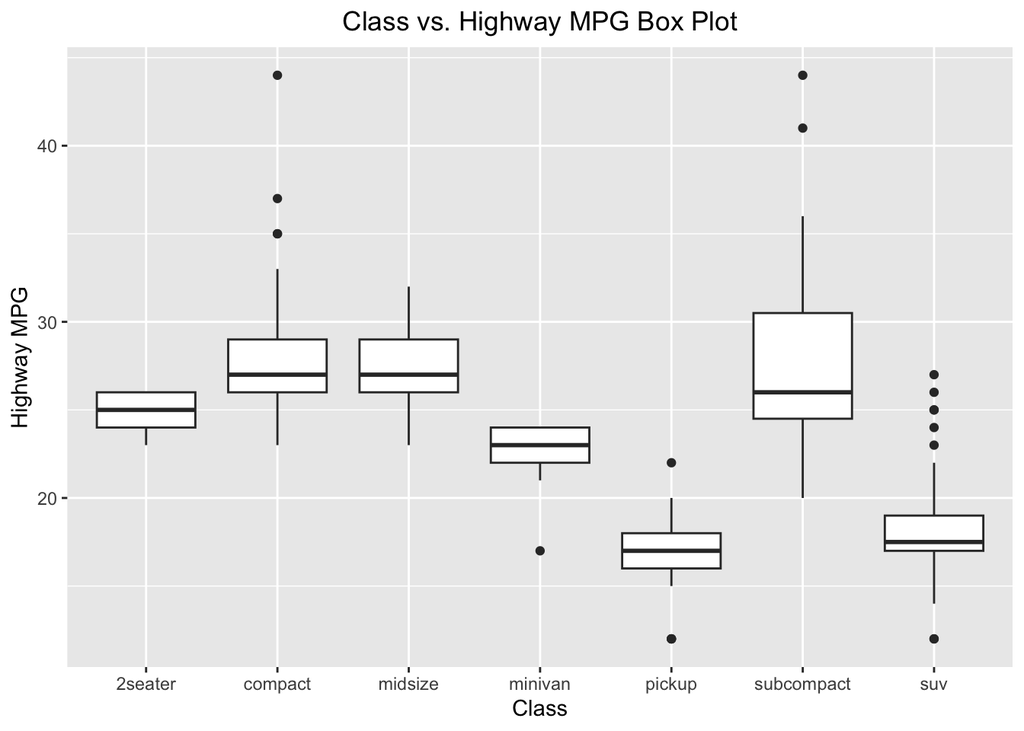

### Computing Basic Statistics

```
[1] 7771.31
```

```
[1] 6979948
```

```
[1] 2641.959
```

```
[1] 2685
```

```
[1] 15352
```

```
[1] 7494
```

```
[1] -0.7928546
```

#### Analysis

There is a strong, negative correlation between *pce* and *psavert* (-0.7929).

### Conducting a t-test

```
    One Sample t-test

data:  tips$tip
t = 5.6253, df = 243, p-value = 5.08e-08
alternative hypothesis: true mean is not equal to 2.5
95 percent confidence interval:
 2.823799 3.172758
sample estimates:
mean of x
 2.998279
```

#### Analysis

*t* is our t-value, which is the standardized test statistic for this data set. Our t-value should be greater than our t statistic we are testing against, so we can reject $H0: mu = 2.50$.  
*df* are the degrees of freedom in this data set.  
*p-value* is the probability that we will get an sample mean under the $H0$. Our p-value (5.08e-08) < 0.05, meaning we can reject $H0$.  
*confidence interval* is 95% - meaning that if we sampled the data randomly, our sample mean would be within the range 95% of the time.  
*sample mean of x* is the mean of our current sample from the data.  
We can reject $H0: mu = 2.50$ because our p-value < 0.05.

### Building a Linear Regression Model

```
# A tibble: 6 × 11
  manufacturer model displ  year   cyl trans      drv     cty   hwy fl    class
  <chr>        <chr> <dbl> <int> <int> <chr>      <chr> <int> <int> <chr> <chr>
1 audi         a4      1.8  1999     4 auto(l5)   f        18    29 p     compa…
2 audi         a4      1.8  1999     4 manual(m5) f        21    29 p     compa…
3 audi         a4      2    2008     4 manual(m6) f        20    31 p     compa…
4 audi         a4      2    2008     4 auto(av)   f        21    30 p     compa…
5 audi         a4      2.8  1999     6 auto(l5)   f        16    26 p     compa…
6 audi         a4      2.8  1999     6 manual(m5) f        18    26 p     compa…
```

```
# A tibble: 6 × 11
  manufacturer model  displ  year   cyl trans      drv     cty   hwy fl    class
  <chr>        <chr>  <dbl> <int> <int> <chr>      <chr> <int> <int> <chr> <chr>
1 volkswagen   passat   1.8  1999     4 auto(l5)   f        18    29 p     mids…
2 volkswagen   passat   2    2008     4 auto(s6)   f        19    28 p     mids…
3 volkswagen   passat   2    2008     4 manual(m6) f        21    29 p     mids…
4 volkswagen   passat   2.8  1999     6 auto(l5)   f        16    26 p     mids…
5 volkswagen   passat   2.8  1999     6 manual(m5) f        18    26 p     mids…
6 volkswagen   passat   3.6  2008     6 auto(s6)   f        17    26 p     mids…
```

```
Call:
lm(formula = hwy ~ displ, data = mpg)

Coefficients:
(Intercept)        displ
     35.698       -3.531
```

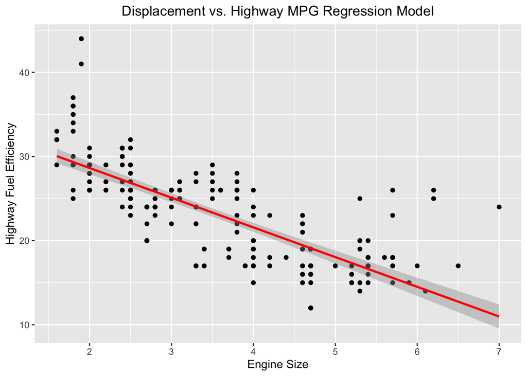

```
Call:
lm(formula = displ ~ hwy, data = mpg)

Coefficients:
(Intercept)          hwy
     7.3676      -0.1662
```

```
Call:
lm(formula = displ ~ hwy, data = mpg)

Residuals:
    Min      1Q  Median      3Q     Max
-1.4126 -0.5710 -0.1105  0.4571  3.6212

Coefficients:
             Estimate Std. Error t value Pr(>|t|)
(Intercept)  7.367570   0.221422   33.27   <2e-16 ***
hwy         -0.166201   0.009157  -18.15   <2e-16 ***
---
Signif. codes:  0 '***' 0.001 '**' 0.01 '*' 0.05 '.' 0.1 ' ' 1

Residual standard error: 0.8323 on 232 degrees of freedom
Multiple R-squared:  0.5868,    Adjusted R-squared:  0.585
F-statistic: 329.5 on 1 and 232 DF,  p-value: < 2.2e-16
```

## Part 3: Basic Importing and Wrangling of Data

### Inspecting and Cleaning the Data

```
  Neighborhood          Class Units YearsBuilt   SqFt   Income IncomePer-SqFt
1    FINANCIAL R9-CONDOMINIUM    42       1920  36500  1332615          36.51
2    FINANCIAL R4-CONDOMINIUM    78       1985 126420  6633257          52.47
3    FINANCIAL RR-CONDOMINIUM   500         NA 554174 17310000          31.24
4    FINANCIAL R4-CONDOMINIUM   282       1930 249076 11776313          47.28
5      TRIBECA R4-CONDOMINIUM   239       1985 219495 10004582          45.58
6      TRIBECA R4-CONDOMINIUM   133       1986 139719  5127687          36.70
  Expense ExpensePerSqFt NetIncome    Value ValuePerSqFt      Boro
1  342005           9.37    990610  7300000       200.00 Manhattan
2 1762295          13.94   4870962 30690000       242.76 Manhattan
3 3543000           6.39  13767000 90970000       164.15 Manhattan
4 2784670          11.18   8991643 67556006       271.23 Manhattan
5 2783197          12.68   7221385 54320996       247.48 Manhattan
6 1497788          10.72   3629899 26737996       191.37 Manhattan
```

### Building a Linear Regression Model

```
Call:
lm(formula = ValuePerSqFt ~ Units + SqFt + Boro, data = housing)

Residuals:
     Min       1Q   Median       3Q      Max
-164.418  -22.692    1.416   26.972  261.122

Coefficients:
                    Estimate Std. Error t value Pr(>|t|)
(Intercept)        4.329e+01  5.330e+00   8.122 6.97e-16 ***
Units             -1.881e-01  2.210e-02  -8.511  < 2e-16 ***
SqFt               2.103e-04  2.087e-05  10.079  < 2e-16 ***
BoroBrooklyn       3.456e+01  5.535e+00   6.244 4.95e-10 ***
BoroManhattan      1.310e+02  5.385e+00  24.327  < 2e-16 ***
BoroQueens         3.299e+01  5.663e+00   5.827 6.35e-09 ***
BoroStaten Island -3.630e+00  9.993e+00  -0.363    0.716
---
Signif. codes:  0 '***' 0.001 '**' 0.01 '*' 0.05 '.' 0.1 ' ' 1

Residual standard error: 43.35 on 2619 degrees of freedom
Multiple R-squared:  0.6009,    Adjusted R-squared:    0.6
F-statistic: 657.2 on 6 and 2619 DF,  p-value: < 2.2e-16
```

## Part 4: Hello World, Data, Statistics and Beyond in Python

### Hello World in Python

```
Hello World!
```

```
Hello Stats!
```

```
Hello World!
```

### Doing Simple Math Calculations

```
3
```

```
15
```

### Installing and importing packages

### Accessing a Built-In Dataset with Python

```
The size of the dataset is (20640, 8)
```

[output not shown]

```
dict_keys(['data', 'target', 'frame', 'target_names', 'feature_names', 'DESCR'])
```

```
LinearRegression()
```

```
[ 4.36693293e-01  9.43577803e-03 -1.07322041e-01  6.45065694e-01
 -3.97638942e-06 -3.78654265e-03 -4.21314378e-01 -4.34513755e-01]
```

### Accessing and Exploring Another Built-in Dataset in Python

```
dict_keys(['data', 'target', 'frame', 'target_names', 'DESCR', 'feature_names', 'filename', 'data_module'])
```

[output not shown]

[output cut: 95 more lines]

[output not shown]

```
   sepal length (cm)  sepal width (cm)  ...  petal width (cm)  species
0                5.1               3.5  ...               0.2   setosa
1                4.9               3.0  ...               0.2   setosa
2                4.7               3.2  ...               0.2   setosa
3                4.6               3.1  ...               0.2   setosa
4                5.0               3.6  ...               0.2   setosa

[5 rows x 5 columns]
```

```
       sepal length (cm)  sepal width (cm)  petal length (cm)  petal width (cm)
count         150.000000        150.000000         150.000000        150.000000
mean            5.843333          3.057333           3.758000          1.199333
std             0.828066          0.435866           1.765298          0.762238
min             4.300000          2.000000           1.000000          0.100000
25%             5.100000          2.800000           1.600000          0.300000
50%             5.800000          3.000000           4.350000          1.300000
75%             6.400000          3.300000           5.100000          1.800000
max             7.900000          4.400000           6.900000          2.500000
```

```
array([[<Axes: title={'center': 'sepal length (cm)'}>,
        <Axes: title={'center': 'sepal width (cm)'}>],
       [<Axes: title={'center': 'petal length (cm)'}>,
        <Axes: title={'center': 'petal width (cm)'}>]], dtype=object)
```

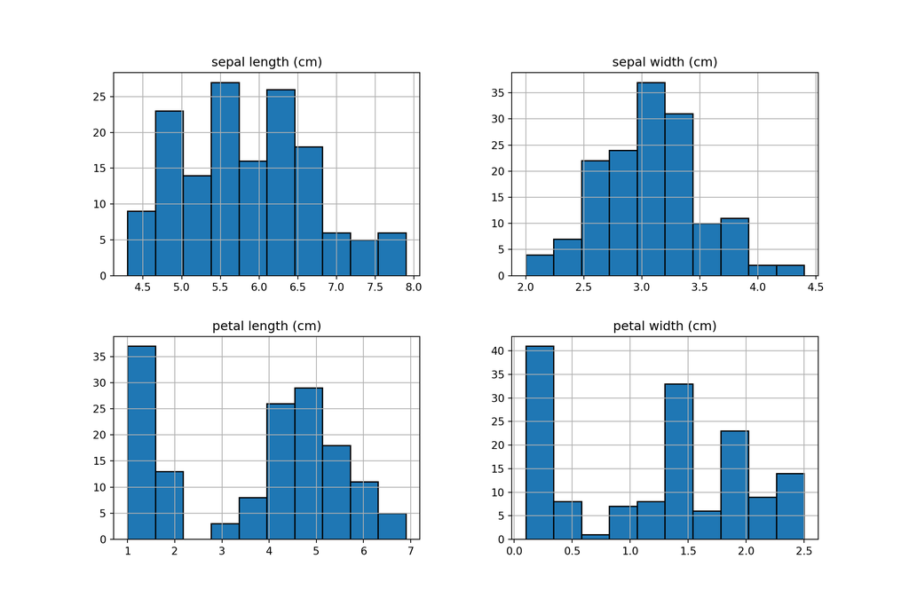

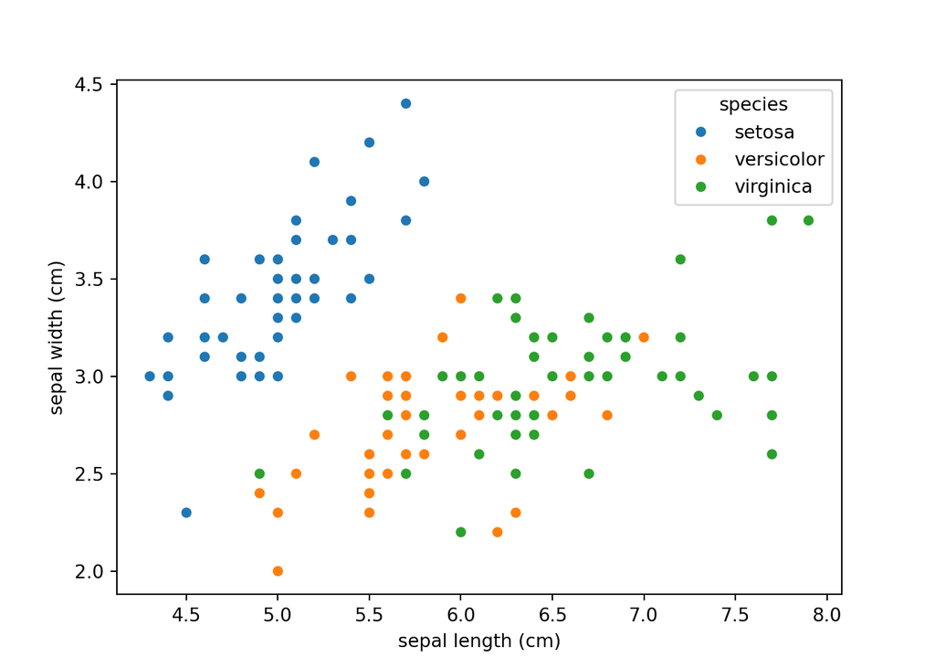

```
LogisticRegression()
```

```
Accuracy: 1.00
```